# Analysis_Reproduce

## Import Needed Libraries

```python
print(__doc__)
import pandas as pd
import numpy as np
import matplotlib as mpl
#mpl.use('TkAgg')
import matplotlib.pyplot as plt
import seaborn as sns
sns.set_style('whitegrid')
%matplotlib inline

#import matplotlib
from pylab import rcParams
rcParams['mathtext.default']='regular'
rcParams['font.size'] = 20
rcParams['axes.labelsize'] = 30
rcParams['legend.fontsize'] = 20
mpl.rc('xtick', labelsize=15)
mpl.rc('ytick', labelsize=15)
sns.set_context('notebook')
sns.set_style('ticks')

from sklearn import tree
from sklearn.ensemble import RandomForestClassifier
from sklearn.tree import DecisionTreeRegressor
from sklearn.ensemble import RandomForestRegressor
from sklearn.ensemble import ExtraTreesRegressor
from sklearn.metrics import confusion_matrix

import itertools

import os

from ggplot import *

import subprocess
import quickspikes as qs
from scipy.integrate import odeint
from scipy.interpolate import UnivariateSpline

from tabulate import tabulate
import tabulate as T
del(T.LATEX_ESCAPE_RULES['$'])
del(T.LATEX_ESCAPE_RULES['\\'])
del(T.LATEX_ESCAPE_RULES['_'])
del(T.LATEX_ESCAPE_RULES['{'])
del(T.LATEX_ESCAPE_RULES['}'])

print(__doc__)
from time import time
from matplotlib import offsetbox
from sklearn import (manifold, datasets, decomposition, ensemble,
                     discriminant_analysis, random_projection)
```

```
Automatically created module for IPython interactive environment
Automatically created module for IPython interactive environment
```

## Load in the Data

```python
neuron_params = pd.read_csv("param_table_no_db.csv").iloc[:,2:]
```

## Neuron Identity for each Epoch

```python
neuron_1_labels = ['4839SW', '72L7E2', 'FGD399']
neuron_2_labels = ['555YZ6', 'D673X6', '5Q5T97']
neuron_3_labels = ['567H6C', '97C25L', '87LSF5'
                 ,'G73N45', 'Q7A364', 'UK59W3']
neuron_4_labels = ['9C88PR', 'R6E486', '386QZV',
                  '5UY366','ZA98N2', '9M29H3']
neuron_5_labels = ['UR7L49', '73VW68', 'CU8L53']
```

## Epochs Producing Best Predictions

```python
neuron_1_labels = ['4839SW', '72L7E2', 'FGD399']
neuron_2_labels = ['555YZ6', 'D673X6', '5Q5T97']
neuron_3_labels = ['567H6C', '97C25L', '87LSF5'
                ,'G73N45', 'Q7A364', 'UK59W3']
#neuron_3_labels = []
neuron_4_labels = ['R6E486', '5UY366', 'ZA98N2', '9M29H3']
neuron_5_labels = ['UR7L49', 'CU8L53']
```

```python
neuron_params['Neuron'] = '0'
neuron_params['Type'] = '0'
neuron_params.ix[neuron_params.epoch_label.isin(neuron_1_labels), 'Neuron'] = '1'
neuron_params.ix[neuron_params.epoch_label.isin(neuron_2_labels), 'Neuron'] = '2'
neuron_params.ix[neuron_params.epoch_label.isin(neuron_3_labels), 'Neuron'] = '3'
neuron_params.ix[neuron_params.epoch_label.isin(neuron_4_labels), 'Neuron'] = '4'
neuron_params.ix[neuron_params.epoch_label.isin(neuron_5_labels), 'Neuron'] = '5'
```

## Label Neuron Type (healthy or 3xTG)

```python
neuron_params.ix[neuron_params.epoch_label.isin(neuron_1_labels), 'Type'] = 'Healthy'
neuron_params.ix[neuron_params.epoch_label.isin(neuron_2_labels), 'Type'] = '3xTG'
neuron_params.ix[neuron_params.epoch_label.isin(neuron_3_labels), 'Type'] = '3xTG'
neuron_params.ix[neuron_params.epoch_label.isin(neuron_4_labels), 'Type'] = 'Healthy'
neuron_params.ix[neuron_params.epoch_label.isin(neuron_5_labels), 'Type'] = 'Healthy'
```

## Drop Bad Values

```python
neuron_params.replace([np.inf, -np.inf], np.nan, inplace = True)
neuron_params.dropna(inplace = True)
print_names = open('print_names_new.txt', 'r').readlines()
print_names = [x.strip() for x in print_names]
feature_dict = dict(zip(list(neuron_params), print_names))
reverse_feature_dict = dict(zip(print_names, list(neuron_params)))
neuron_params = neuron_params.rename(index = str, columns = feature_dict)

neuron_params = neuron_params[neuron_params['Type'] != '0']
all_neurons = np.unique(neuron_params['epoch label'])
```

## Exploratory Data Analysis

### One striking difference between 3xTG and healthy neurons is that the 3xTG neurons seem to be more excitable - lower threshold for spiking, lower step current required to cause spiking. Another is that the spike width appears to be larger in 3xTG cells than in healthy cells.

This is supported by the fact that when $\theta_m$ (Vmo) and $\sigma_m$ (dVm) are plotted against each other, we find a reasonably well defined boundary between the sets of estimated values for each neuron type. Whenever $\theta_m$ increases in a given family of estimates, $\sigma_m$ also increases to compensate, keeping the overall excitability of the neuron relatively constant.

```python
def plot_scatter(param1, param2, handle = 'Type'):

    if handle == 'Type':
        palette = dict([('Healthy', 'b'), ('3xTG', 'r')])
    else:
        palette = None

    sns.lmplot(param1, param2,
    data = neuron_params,
    fit_reg = False,
    hue = handle,
    palette= palette,
    scatter_kws={'alpha':0.3})
    plt.xlabel(param1)
    #plt.xlim((-200.0,0.0))
    plt.ylabel(param2)
    #plt.ylim((-400.0,0.0))
    plt.savefig('{0}_{1}_{2}.png'.format(reverse_feature_dict[param1], reverse_feature_dict[param2], handle))
```

```python
#neuron_params[neuron_params['Neuron'] != '2'].mean()
```

```python
#neuron_params[neuron_params['Neuron'] == '2'].mean()
#feature_dict['threshold_gNa_dec']
feature_dict['max_dINa_dt_inc']
```

```
'Max $\\dot{I}_{Na}$ Upstroke (pA/ms)'
```

```python
corrs = neuron_params.corr()

corrs_thres_volt = corrs[feature_dict['threshold_step_current']].sort_values(axis=0, ascending=False, inplace=False)

#corrs_thres_volt
```

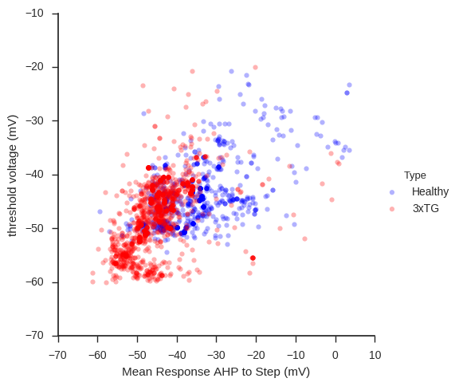

```python
param1 = feature_dict['mean_ahp']
param2 = feature_dict['threshold_voltage']
#param1 = 'Voltage at Max $\dot{I}_{Na}$ Upstroke (mV)'
#param1 = feature_dict['threshold_dIK_inc']
#param1 = 'Voltage at Max $I$ Upstroke (mV)'

#param1 = corrs_thres_volt.index[6]


#param1 = feature_dict['threshold_gNa_dec']
#param1 = feature_dict['width']
#param2 = feature_dict['threshold_voltage']
#param1 = feature_dict['EL']
#param1 = feature_dict['threshold_gNa_inc']

plot_scatter(param1, param2, handle ='Type')
```

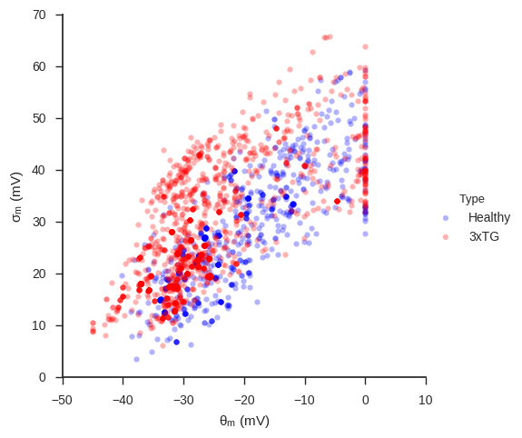

```python
param1 = '$\\theta_m$ (mV)'
param2 = '$\\sigma_m$ (mV)'

sns.lmplot(param1, param2,
          data = neuron_params,
          fit_reg = False,
          hue = 'Type',
          palette=dict([('Healthy', 'b'), ('3xTG', 'r')]),
          scatter_kws={'alpha':0.3})
plt.xlabel(param1)
plt.ylabel(param2)
plt.savefig('{0}_{1}.png'.format(reverse_feature_dict[param1], reverse_feature_dict[param2]))
```

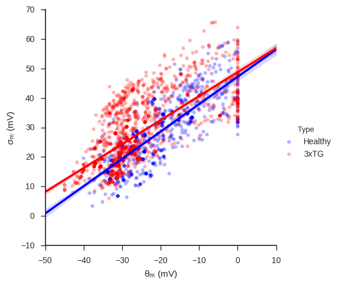

```python
param1 = '$\\theta_m$ (mV)'
param2 = '$\\sigma_m$ (mV)'

sns.lmplot(param1, param2,
          data = neuron_params,
          fit_reg = True,
          hue = 'Type',
          palette=dict([('Healthy', 'b'), ('3xTG', 'r')]),
          scatter_kws={'alpha':0.3})
plt.xlabel(param1)
plt.ylabel(param2)
plt.savefig('{0}_{1}_regr.png'.format(reverse_feature_dict[param1], reverse_feature_dict[param2]))
```

One 3xTG neuron appears to primarily contribute to this pattern of separation. Since there are only 2 3xTG neurons and 3 healthy neurons, any conclusions we draw about the two populations is tentative.

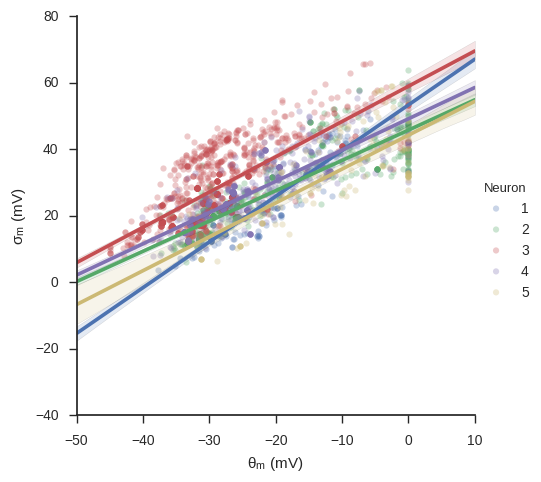

```python
param1 = '$\\theta_m$ (mV)'
param2 = '$\\sigma_m$ (mV)'

sns.lmplot(param1, param2,
          data = neuron_params,
          fit_reg = True,
          hue = 'Neuron',
          scatter_kws={'alpha':0.3})
plt.xlabel(param1)
plt.ylabel(param2)
plt.savefig('{0}_{1}_regr_ident.png'.format(reverse_feature_dict[param1], reverse_feature_dict[param2]))
```

We find, using variable importance in random forests, that the half-width of a neuron and the voltage at half inactivation ($\theta_h$) for the sodium current are key distinguishing features between 3xTG healthy neurons. Our decision tree uses width as the first feature to split on. Models with larger estimated widths are much more likely to be classified as 3xTG.

The results of the plot of $\theta_m$ against $\sigma_m$ suggests that an important feature distinguishing neurons of the two classes from each other is overall excitability. Therefore an engineered feature containing this information is desirable. Two features in particular have this property. One is the maximum applied step current which will not cause the neuron to generate an action potential. The other is the voltage at which this occurs.

The separation between the two classes of neurons is especially striking when the half-width and the threshold step current are plotted against each other. This is reflected in the decision tree structure, where these features are consecutive, informative splits.

We would likely see even better splits if we included $\theta_h$ in a third dimension, as it is the third consecutive split in our decision tree structure, and it is also fairly informative as measured by the gini information. A gini value close to 0.5 corresponds to a good split, and these values are about 0.5, 0.3, and 0.2, respectively.

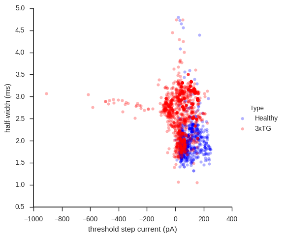

```python
param1 = 'threshold step current (pA)'
param2 = 'half-width (ms)'

sns.lmplot(param1, param2,
          data = neuron_params,
          fit_reg = False,
          hue = 'Type',
          palette=dict([('Healthy', 'b'), ('3xTG', 'r')]),
          scatter_kws={'alpha':0.3})
plt.xlabel(param1)
plt.ylabel(param2)
plt.savefig('{0}_{1}.png'.format(reverse_feature_dict[param1], reverse_feature_dict[param2]))
```

The split between the two groups when $\theta_h$ and the threshold step current are plotted is not quite as clear, but the two quantities seem to be associated with each other, though in this case why they are related is not as clear. $\theta_h$ governs where $I_{Na}$ inactivates and how fast. $I_{Na}$ should turn off more slowly in the range of threshold voltages. We verify below that the threshold voltage and the applied current at which action potentials are generated are correlated. We see plots of threshold voltage or minimal threshold current against $\theta_h$ both have the same pattern and seem to split 3xTG and healthy neurons from each other well.

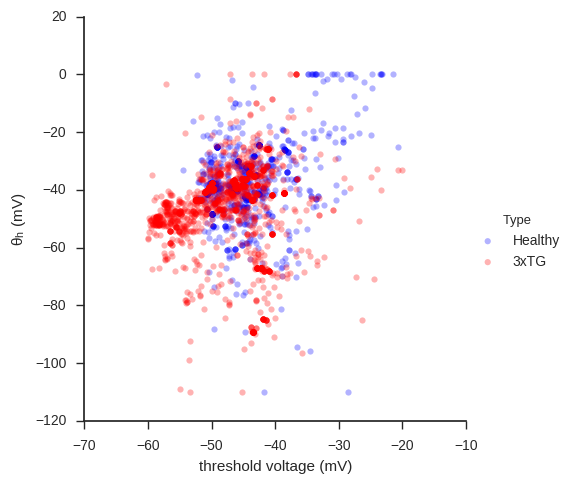

```python
param1 = 'threshold voltage (mV)'
param2 = '$\\theta_h$ (mV)'

sns.lmplot(param1, param2,
          data = neuron_params,
          fit_reg = False,
          hue = 'Type',
          palette=dict([('Healthy', 'b'), ('3xTG', 'r')]),
          scatter_kws={'alpha':0.3})
plt.xlabel(param1)
plt.ylabel(param2)
plt.savefig('{0}_{1}.png'.format(reverse_feature_dict[param1], reverse_feature_dict[param2]))
```

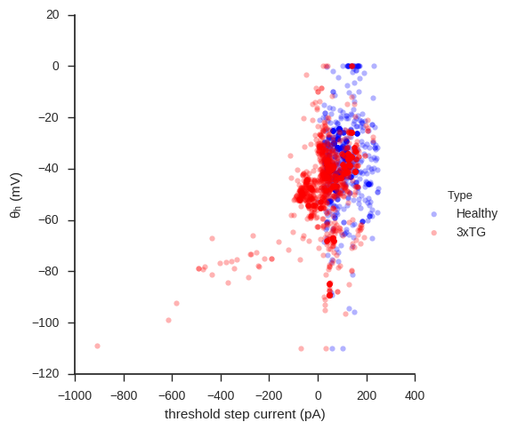

```python
param1 = 'threshold step current (pA)'
param2 = '$\\theta_h$ (mV)'

sns.lmplot(param1, param2,
          data = neuron_params,
          fit_reg = False,
          hue = 'Type',
          palette=dict([('Healthy', 'b'), ('3xTG', 'r')]),
          scatter_kws={'alpha':0.3})
plt.xlabel(param1)
plt.ylabel(param2)
plt.savefig('{0}_{1}.png'.format(reverse_feature_dict[param1], reverse_feature_dict[param2]))
```

We check below that threshold step current and threshold voltage are related to each other.

As we would expect, the two quantities are correlated with each other. It is a little hard to tell from the plot, but healthy cells tend towards larger values of both parameters than do 3xTG cells. Some of these cells are excitable enough that they will generate spikes even at negative applied step currents.

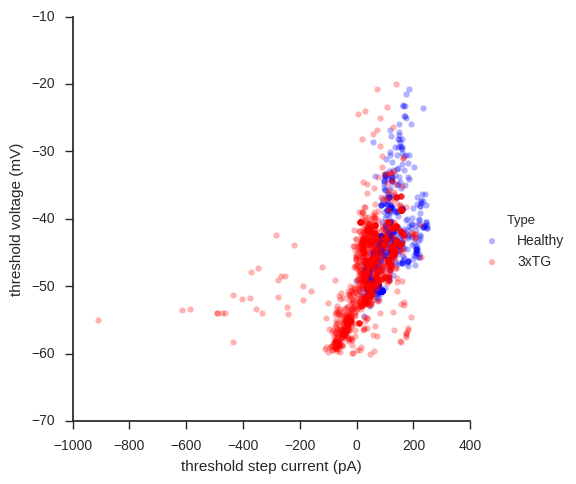

```python
param1 = 'threshold step current (pA)'
param2 = 'threshold voltage (mV)'

sns.lmplot(param1, param2,
          data = neuron_params,
          fit_reg = False,
          hue = 'Type',
          palette=dict([('Healthy', 'b'), ('3xTG', 'r')]),
          scatter_kws={'alpha':0.3})
plt.xlabel(param1)
plt.ylabel(param2)
plt.savefig('{0}_{1}.png'.format(reverse_feature_dict[param1], reverse_feature_dict[param2]))
```

The rate of change of $I_{Na}$ is a good proxy for $\theta_m$. Because $I_{Na}$ activates very quickly and inactivates relatively more slowly, we expect that the rate of change of $I_{Na}$ with respect to time during an action potential will be maximum when we are the steepest part of the sigmoid, which is $\theta_m$. If we plot these two quantities against each other, we find that this is indeed the case. The correspondence is not exact since the rate of change of $I_Na$ also depends on voltage and $h$ is changing, but we will nevertheless use the voltage at maximum $\dot{I}_{Na}$ as a proxy for $\theta_m$.

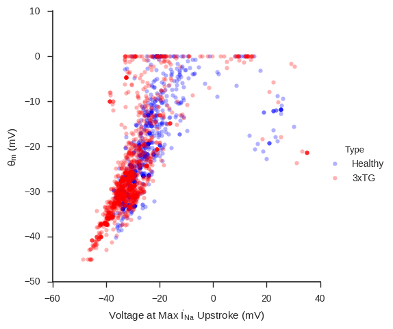

```python
param1 = 'Voltage at Max $\\dot{I}_{Na}$ Upstroke (mV)'
param2 = '$\\theta_m$ (mV)'

sns.lmplot(param1, param2,
          data = neuron_params,
          fit_reg = False,
          hue = 'Type',
          palette=dict([('Healthy', 'b'), ('3xTG', 'r')]),
          scatter_kws={'alpha':0.3})
plt.xlabel(param1)
plt.ylabel(param2)
plt.savefig('{0}_{1}.png'.format(reverse_feature_dict[param1], reverse_feature_dict[param2]))
```

We can visualize the relationship between the voltage of maximum $\dot{I}_{Na}$ and threshold step current. As we would expect, a stronger step current is required to elicit an action potential, and we see that the separation between the two types of neurons is a little better in two dimensions than it is in one dimension.

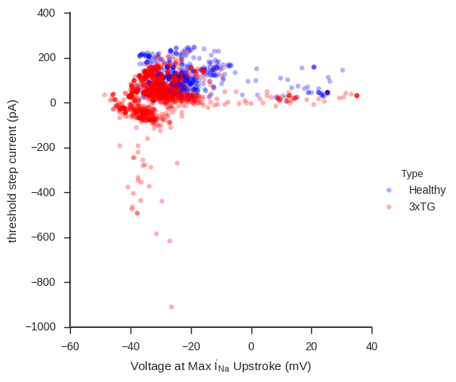

```python
param1 = 'Voltage at Max $\\dot{I}_{Na}$ Upstroke (mV)'
param2 = 'threshold step current (pA)'

sns.lmplot(param1, param2,
          data = neuron_params,
          fit_reg = False,
          hue = 'Type',
          palette=dict([('Healthy', 'b'), ('3xTG', 'r')]),
          scatter_kws={'alpha':0.3})
plt.xlabel(param1)
plt.ylabel(param2)
plt.savefig('{0}_{1}.png'.format(reverse_feature_dict[param1], reverse_feature_dict[param2]))
```

We also expect to see some separation when we look at the threshold voltage for generating a spike, and we expect this threshold voltage to be correlated with the voltage at which $I_{Na}$ turns on. We do see that the separation is not perfect, as the differences between the two kinds of neurons is multifaceted and includes spike width, which is a proxy for parameters like $\sigma_{ht}$, $t_h$, $g_K$, and $\theta_n$, which also differ between the two classes of neurons. There are also other interactions of parameters which mostly account for these differences. As the differences between the two classes of neurons is rather subtle, these interactions may become more complicated as one wishes to decrease the error rate, but one need not traverse the decision tree too deeply to find good separation between the two classes.

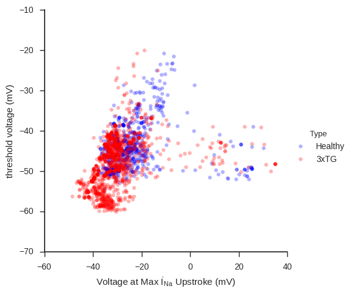

```python
param1 = 'Voltage at Max $\\dot{I}_{Na}$ Upstroke (mV)'
param2 = 'threshold voltage (mV)'

sns.lmplot(param1, param2,
          data = neuron_params,
          fit_reg = False,
          hue = 'Type',
          palette=dict([('Healthy', 'b'), ('3xTG', 'r')]),
          scatter_kws={'alpha':0.3})
plt.xlabel(param1)
plt.ylabel(param2)
plt.savefig('{0}_{1}.png'.format(reverse_feature_dict[param1], reverse_feature_dict[param2]))
```

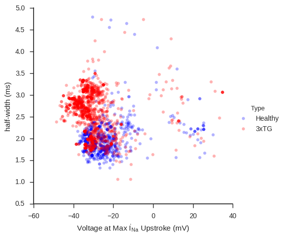

```python
param1 = 'Voltage at Max $\\dot{I}_{Na}$ Upstroke (mV)'
param2 = 'half-width (ms)'

sns.lmplot(param1, param2,
          data = neuron_params,
          fit_reg = False,
          hue = 'Type',
          palette=dict([('Healthy', 'b'), ('3xTG', 'r')]),
          scatter_kws={'alpha':0.3})
plt.xlabel(param1)
plt.ylabel(param2)
plt.savefig('{0}_{1}.png'.format(reverse_feature_dict[param1], reverse_feature_dict[param2]))
```

## Attempts at Manifold Clustering

```python
all_neurons = np.unique(neuron_params['epoch label'])
neuron_params.replace([np.inf, -np.inf], np.nan, inplace = True)
neuron_params.dropna(inplace = True)
trains = [neuron_params[neuron_params['epoch label'] == neuron].sample(frac=0.9) for neuron in all_neurons]
tests = [neuron_params[neuron_params['epoch label'] == all_neurons[i]].loc[~neuron_params[neuron_params['epoch label'] == all_neurons[i]].index.isin(trains[i].index)] for i in range(len(all_neurons))]
train = pd.concat(trains)
test = pd.concat(tests)
drop = [feature_dict['epoch_label'], feature_dict['Neuron'], feature_dict['Type']]# + list(neuron_params)[21:]
X_train, Y_train, X_test, Y_test = split_train_test(neuron_params, 'Type', drop = drop)
X = X_train.as_matrix()
Y = [int(x == '3xTG') for x in list(Y_train.values)]

n_samples, n_features = X.shape
n_neighbors = 30
```

```python
# Scale and visualize the embedding vectors
digits = datasets.load_digits(n_class=6)
def plot_embedding(X, title=None):

    x_min, x_max = np.min(X, 0), np.max(X, 0)
    X = (X - x_min) / (x_max - x_min)

    plt.figure()
    ax = plt.subplot(111)
    colors = ['blue', 'red']
    for i in range(X.shape[0]):
        plt.text(X[i, 0], X[i, 1], str(Y_train.values[i]),
                 color=colors[Y[i]],
                 fontdict={'weight': 'bold', 'size': 9})

    if hasattr(offsetbox, 'AnnotationBbox'):
        # only print thumbnails with matplotlib > 1.0
        shown_images = np.array([[1., 1.]])  # just something big
        for i in range(X_train.shape[0]):
            dist = np.sum((X[i] - shown_images) ** 2, 1)
            if np.min(dist) < 4e-3:
                # don't show points that are too close
                continue
            shown_images = np.r_[shown_images, [X[i]]]



            imagebox = offsetbox.AnnotationBbox(
                offsetbox.OffsetImage(digits.images[len(Y_train.values[i])], cmap=plt.cm.gray_r),
                X[i])
            ax.add_artist(imagebox)
    plt.xticks([]), plt.yticks([])
    if title is not None:
        plt.title(title)
```

```
Computing random projection
2213 2213
```

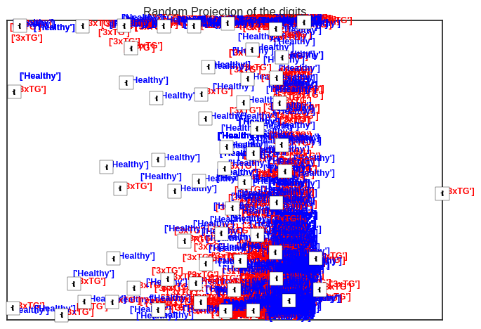

```python
#----------------------------------------------------------------------
# Random 2D projection using a random unitary matrix
print("Computing random projection")
rp = random_projection.SparseRandomProjection(n_components=2, random_state=42)
X_projected = rp.fit_transform(X)
print(len(X), len(X_projected))
plot_embedding(X_projected, "Random Projection of the digits")
```

```
Computing PCA projection
```

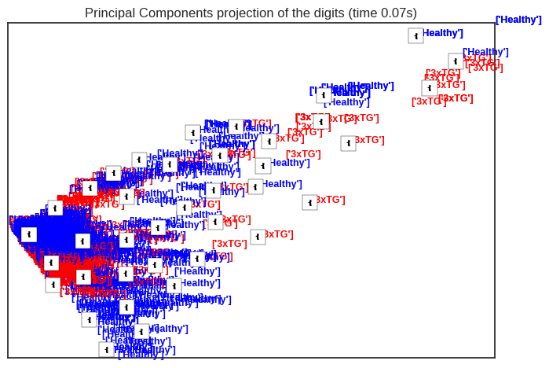

```python
#----------------------------------------------------------------------
# Projection on to the first 2 principal components

print("Computing PCA projection")
t0 = time()
X_pca = decomposition.TruncatedSVD(n_components=2).fit_transform(X)
plot_embedding(X_pca,
               "Principal Components projection of the digits (time %.2fs)" %
               (time() - t0))
```

```
Computing Isomap embedding
Done.
```

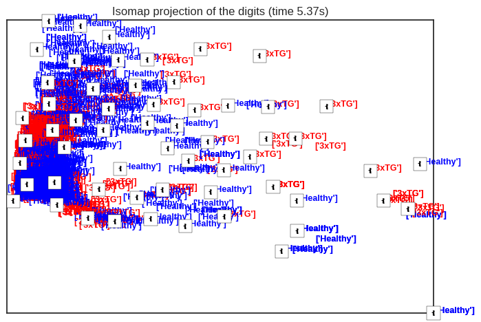

```python
# Isomap projection of the digits dataset
print("Computing Isomap embedding")
t0 = time()
X_iso = manifold.Isomap(n_neighbors, n_components=2).fit_transform(X)
print("Done.")
plot_embedding(X_iso,
               "Isomap projection of the digits (time %.2fs)" %
               (time() - t0))
```

```
Computing LLE embedding
Done. Reconstruction error: -2.58369e-17
```

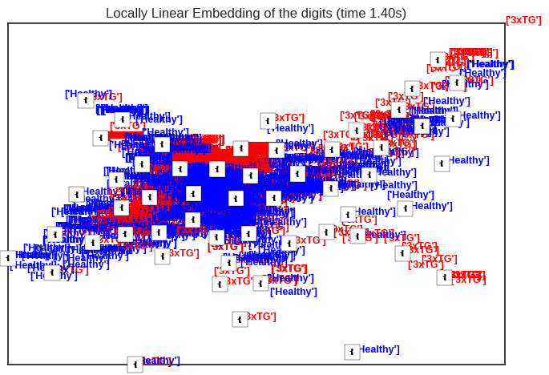

```python
# Locally linear embedding of the digits dataset
print("Computing LLE embedding")
clf = manifold.LocallyLinearEmbedding(n_neighbors, n_components=2,
                                      method='standard')
t0 = time()
X_lle = clf.fit_transform(X)
print("Done. Reconstruction error: %g" % clf.reconstruction_error_)
plot_embedding(X_lle,
               "Locally Linear Embedding of the digits (time %.2fs)" %
               (time() - t0))
```

```
Computing MDS embedding
Done. Stress: 185075034005791.250000
```

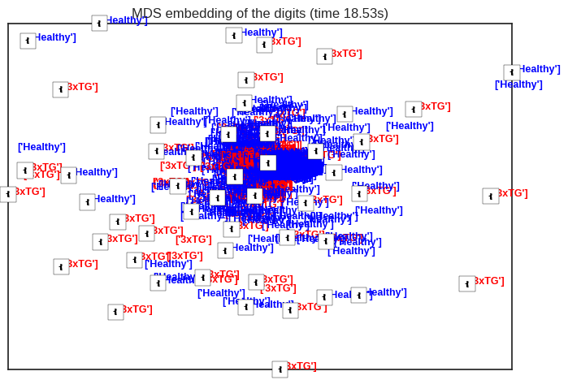

```python
# MDS  embedding of the digits dataset
print("Computing MDS embedding")
clf = manifold.MDS(n_components=2, n_init=1, max_iter=100)
t0 = time()
X_mds = clf.fit_transform(X)
print("Done. Stress: %f" % clf.stress_)
plot_embedding(X_mds,
               "MDS embedding of the digits (time %.2fs)" %
               (time() - t0))
```

```
Computing Totally Random Trees embedding
```

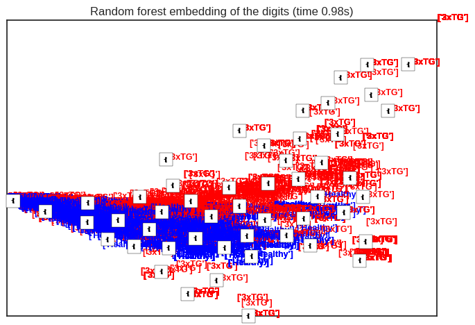

```python
# Random Trees embedding of the digits dataset
print("Computing Totally Random Trees embedding")
hasher = ensemble.RandomTreesEmbedding(n_estimators=200, max_depth=18)
t0 = time()
X_transformed = hasher.fit_transform(X)


#clf = manifold.MDS(n_components=2, n_init=1, max_iter=100)
#X_reduced = clf.fit_transform(X_transformed.toarray())

pca = decomposition.TruncatedSVD(n_components=2)
X_reduced = pca.fit_transform(X_transformed)

plot_embedding(X_reduced,
               "Random forest embedding of the digits (time %.2fs)" %
               (time() - t0))
```

```
Computing Spectral embedding
```

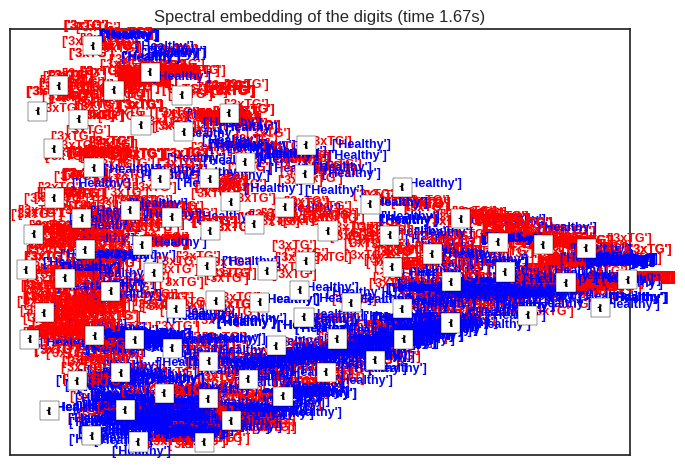

```python
# Spectral embedding of the digits dataset
print("Computing Spectral embedding")
embedder = manifold.SpectralEmbedding(n_components=2, random_state=0,
                                      eigen_solver="arpack")
t0 = time()
X_se = embedder.fit_transform(X)

plot_embedding(X_se,
               "Spectral embedding of the digits (time %.2fs)" %
               (time() - t0))
```

```
Computing t-SNE embedding
```

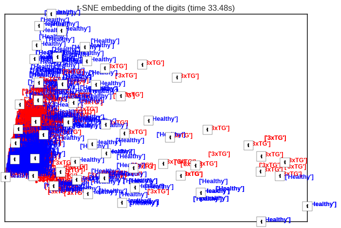

```python
# t-SNE embedding of the digits dataset
print("Computing t-SNE embedding")
tsne = manifold.TSNE(n_components=2, init='pca', random_state=0)
t0 = time()
X_tsne = tsne.fit_transform(X)

plot_embedding(X_tsne,
               "t-SNE embedding of the digits (time %.2fs)" %
               (time() - t0))

plt.show()
```

## Constructing Neuron Identity from Predictors

We assign our predictors and labels divide the data into training and test sets. At first we are interested in seeing whether we can use information from the predictors to tell us what the neuron identity of each epoch label is. We will do this by looking for the errors in our classification algorithm. The tool to look at these errors is the confusion matrix, which we will visualize below.

```python
def plot_confusion_matrix(cm, classes,
                          normalize=False,
                          title='Confusion matrix',
                          cmap=plt.cm.Blues):
    """
    This function prints and plots the confusion matrix.
    Normalization can be applied by setting `normalize=True`.
    """
    plt.figure(figsize = (20,20))
    plt.imshow(cm, interpolation='nearest', cmap=cmap)
    plt.title(title)
    plt.colorbar()
    tick_marks = np.arange(len(classes))
    plt.xticks(tick_marks, classes, rotation=45)
    plt.yticks(tick_marks, classes)

    if normalize:
        cm = cm.astype('float') / cm.sum(axis=1)[:, np.newaxis]
        print("Normalized confusion matrix")
    #else:
        print('Confusion matrix, without normalization')

    #print(cm)

    thresh = cm.max() / 2.
    for i, j in itertools.product(range(cm.shape[0]), range(cm.shape[1])):
        plt.text(j, i, cm[i, j],
                 horizontalalignment="center",
                 color="white" if cm[i, j] > thresh else "black")

    plt.tight_layout()
    plt.ylabel('True label')
    plt.xlabel('Predicted label')
    plt.tight_layout()
    plt.savefig('confusion_matrix.png')
```

```python
predictors = list(set(neuron_params) - set(['epoch label', 'Neuron', 'Type']))
all_neurons = np.unique(neuron_params['epoch label'])
neuron_params.replace([np.inf, -np.inf], np.nan, inplace = True)
neuron_params.dropna(inplace = True)
trains = [neuron_params[neuron_params['epoch label'] == neuron].sample(frac=0.3) for neuron in all_neurons]
tests = [neuron_params[neuron_params['epoch label'] == all_neurons[i]].loc[~neuron_params[neuron_params['epoch label'] == all_neurons[i]].index.isin(trains[i].index)] for i in range(len(all_neurons))]
train = pd.concat(trains)
test = pd.concat(tests)
drop = ['epoch label', 'Neuron', 'Type'] + list(neuron_params)[21:]
X_train = train.drop(drop, axis = 1)
Y_train = train['epoch label']
X_test = test.drop(drop, axis = 1)
Y_test = test['epoch label']
```

### Random Forests

I tested a number of machine learning algorithms and found that random forests had the best performance in assigning neuron labels given the data set I examined. Random forests uses an average of decision trees trained from random samples of the training data. This classification algorithm is good at detecting nonlinear interactions between parameters, which is nice because that means we don't have to do as much feature engineering to do classification well. The disadvantage is that it is a bit of a black box and it is hard to tell why the algorithm worked and what the differences are between the different categories. Since HH models are nonlinear and it can be difficult to interpret what the differences are between sets of estimated parameters, it is not clear whether one could design simple features which would help distinguish different neurons from each other.

```python
random_forest = RandomForestClassifier(n_estimators=100)

random_forest.fit(X_train, Y_train)

Y_pred = random_forest.predict(X_test)

random_forest.score(X_test, Y_test)
```

```
0.85540069686411146
```

We print out the accuracy of our algorithm above, and below we will plot the confusion matrix. We can use the mistakes of the random forests algorithm to correctly guess which epochs are in fact from the same neuron.

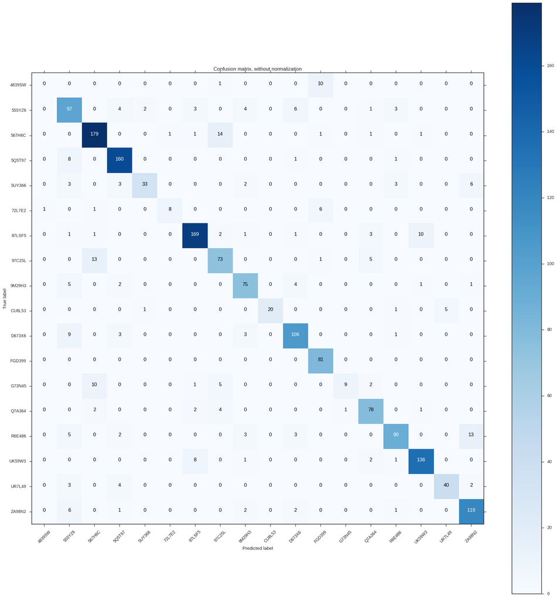

```python
# Compute confusion matrix
cnf_matrix = confusion_matrix(Y_test, Y_pred)
np.set_printoptions(precision=2)
class_names = np.unique(Y_train)

# Plot non-normalized confusion matrix
plt.figure()
plot_confusion_matrix(cnf_matrix, classes=class_names,
                      title='Confusion matrix, without normalization')

# Plot normalized confusion matrix
#plt.figure()
#plot_confusion_matrix(cnf_matrix, classes=class_names, normalize=True,
#                      title='Normalized confusion matrix')

plt.show()
```

We can print out 10 of the most important features which the algorithm use to distinguish the epochs from each other.

```python
sorted(zip(X_train, random_forest.feature_importances_), key=lambda x: x[1], reverse = True)[0:10]
```

```
[('Voltage at Min $g_{K}$ Downstroke (mV)', 0.038373994494604685),
 ('Voltage at Min $g_{Na}$ Downstroke (mV)', 0.036386558056321357),
 ('Voltage at Min $I_{Na} Upstroke (mV)', 0.036213352757642953),
 ('Voltage at Min $g_{Na}$ Upstroke (mV)', 0.035106754118031019),
 ('Voltage at Min $I_{Na} Downstroke (mV)', 0.034022599312166502),
 ('Voltage at Min $g$ Downstroke (mV)', 0.031536807166626858),
 ('threshold step current (pA)', 0.030925394295507603),
 ('$C_m$ (pF)', 0.030851890180281734),
 ('Voltage at Min $g_{K}$ Upstroke (mV)', 0.029048844850462094),
 ('threshold voltage (mV)', 0.0260268609500055)]
```

## Determining Features Distinguishing 3xTG and Healthy Neurons

Next, we can train a random forests algorithm to determine which features are the most important in distinguishing healthy and 3xTG neurons from each other. We drop a number of features that are not useful in distinguishing these classes since the difference in features reflect superficial differences in the stimulating currents eliciting the recorded data.

```python
def split_train_test(neuron_params, label_vars, drop = []):
    trains = [neuron_params[neuron_params['epoch label'] == neuron].sample(frac=0.9) for neuron in all_neurons]
    tests = [neuron_params[neuron_params['epoch label'] == all_neurons[i]].loc[~neuron_params[neuron_params['epoch label'] == all_neurons[i]].index.isin(trains[i].index)] for i in range(len(all_neurons))]
    train = pd.concat(trains)
    test = pd.concat(tests)

    if isinstance(label_vars, (str)):
        label_vars = [label_vars]

    drop1 = [x for x in list(train) if (('Na' in x) and ('Min' in x) and ('dot' not in x)) or (('K' in x) and ('I' in x) and ('Max' in x) and ('dot' not in x))]
    drop2 = [x for x in list(train) if ('$g$' in x or '$g_' in x) and ('Min' in x)]
    #drop3 = [x for x in list(train) if ('freq' in x)]
    drop3 = ['Mean Response AHP to Step (mV)', 'Max Response AHP to Step (mV)']
    drop4 = [feature_dict[label_var] for label_var in label_vars] + [feature_dict['epoch_label'], feature_dict['Neuron'], feature_dict['Type'], 'Min m']
    drop5 = [x for x in list(train) if ('dot{I}$' in x) or ('$I$' in x)]
    drop6 = [x for x in neuron_params if 'infty' in x]
    drop7 = ['Max m', 'Max h', 'Max n', 'Min m', 'Min h', 'Min n', 'Min $\dot{g}_{K}$ Upstroke (nS/ms)']
    drop8 = [x for x in neuron_params if '$g$' in x]
    drop9 = [x for x in neuron_params if 'dot{g}$' in x]
    drop10 = ['Voltage at Max $\dot{I}_{K}$ Upstroke (mV)',
             'Voltage at Min $\dot{g}_{Na}$ Downstroke (mV)',
             'Voltage at Max $g_{Na}$ Downstroke (mV)',
             'Voltage at Max $\dot{g}_{K}$ Upstroke (mV)',
             'Voltage at Min $\dot{I}_{K}$ Downstroke (mV)',
             'Voltage at Min $\dot{I}_{K}$ Upstroke (mV)',
             'Voltage at Min $\dot{g}_{Na}$ Upstroke (mV)',
             'Voltage at Min $I_{K}$ Upstroke (mV)',
             'Voltage at Max $\dot{g}_{Na}$ Downstroke (mV)',
             'Voltage at Max $\dot{g}_{K}$ Downstroke (mV)',
             'Voltage at Min $\dot{g}_{K}$ Upstroke (mV)']

    drop_set = drop + drop1 + drop2 + drop3 + drop4 + drop5 + drop6 + drop7 + drop8 + drop9 + drop10

    X_train = train.drop(drop_set, axis = 1)
    Y_train = train[[feature_dict[label_var] for label_var in label_vars]]
    X_test = test.drop(drop_set, axis = 1)
    Y_test = test[[feature_dict[label_var] for label_var in label_vars]]

    return X_train, Y_train, X_test, Y_test

def get_features_used(X_train, feature, handle = ''):

    features = list(X_train)
    raw_features = [reverse_feature_dict[x] for x in features]

    features_used = zip(features, raw_features)

    headers = ['Feature', 'Feature Abbreviation']
    save_table = tabulate(features_used, headers, tablefmt = 'latex')
    file = open('features_used_{0}_{1}.txt'.format(feature, handle), 'w')
    file.write(save_table)
    file.close()

def save_var_imp(var_imps, feature, header):
    var_imps =  [list(x) for x in var_imps]

    save_table = tabulate(var_imps, header, tablefmt = 'latex', floatfmt=".3f")
    file = open('var_imps_{0}.tex'.format(feature), 'w')
    file.write(save_table)
    file.close()

def train_forest(X_train, Y_train, X_test, Y_test):
    # Random Forests

    random_forest = RandomForestClassifier(n_estimators=100, max_depth = 8)

    random_forest.fit(X_train, Y_train)

    Y_pred = random_forest.predict(X_test)

    print("Random Forest Accuracy", random_forest.score(X_test, Y_test))

    return random_forest

def train_tree(X_train, Y_train, X_test, Y_test):

    #Decision tree
    tree_clf = tree.DecisionTreeClassifier(max_depth = 3)

    tree_clf.fit(X_train, Y_train)

    Y_pred = tree_clf.predict(X_test)

    print("Decision Tree Accuracy (Depth 3)", tree_clf.score(X_test, Y_test))

    return tree_clf

def make_tree_fig(tree_clf, X_train, feature, handle = ''):

    train_features = list(X_train)
    train_features = [reverse_feature_dict[x] for x in train_features]
    with open("tree.dot", 'w') as f:
        f = tree.export_graphviz(tree_clf, out_file=f,feature_names=train_features,
                         class_names=np.unique(neuron_params['Type']),
                          filled=True, rounded=True,
                         special_characters=True)
    print('making tree')
    subprocess.call('dot -Tpdf tree.dot -o tree_{0}_{1}.pdf'.format(feature, handle), shell = True)
        #subprocess.call('dot -Tpdf tree.dot -o tree.pdf', shell = True)
    os.unlink('tree.dot') #unlink dot file

import subprocess
import os

def get_var_imps_and_trees():
    X_train, Y_train, X_test, Y_test = split_train_test(neuron_params, 'Type', drop = [feature_dict['Cm'], feature_dict['gL']])

    random_forest = train_forest(X_train, Y_train, X_test, Y_test)

    var_imp2 = sorted(zip(X_train, random_forest.feature_importances_), key=lambda x: x[1], reverse = True)[0:20]
    print('full', var_imp2, '\n')

    tree_clf = train_tree(X_train, Y_train, X_test, Y_test)
    make_tree_fig(tree_clf, X_train, 'Type', handle = 'full')

    get_features_used(X_train, 'Type', handle = 'full')

    X_train, Y_train, X_test, Y_test = split_train_test(neuron_params, 'Type', drop = [])

    random_forest = train_forest(X_train, Y_train, X_test, Y_test)

    print('full_all', var_imp2, '\n')

    var_imp1 = sorted(zip(X_train, random_forest.feature_importances_), key=lambda x: x[1], reverse = True)[0:20]
    print('full', var_imp1, '\n')

    tree_clf = train_tree(X_train, Y_train, X_test, Y_test)
    make_tree_fig(tree_clf, X_train, 'Type', handle = 'full_all')

    get_features_used(X_train, 'Type', handle = 'full_all')

    X_train, Y_train, X_test, Y_test = split_train_test(neuron_params, 'Type', drop = list(neuron_params)[21:])#+
                                                   #[feature_dict['Cm'], feature_dict['gL']])

    random_forest = train_forest(X_train, Y_train, X_test, Y_test)

    var_imp3 = sorted(zip(X_train, random_forest.feature_importances_), key=lambda x: x[1], reverse = True)[0:20]
    print('params_all', var_imp3, '\n')

    tree_clf = train_tree(X_train, Y_train, X_test, Y_test)
    make_tree_fig(tree_clf, X_train, 'Type', handle = 'params_all')

    get_features_used(X_train, 'Type', handle = 'params_all')

    X_train, Y_train, X_test, Y_test = split_train_test(neuron_params, 'Type', drop = list(neuron_params)[21:]+
                                                   [feature_dict['Cm'], feature_dict['gL']])
    random_forest = train_forest(X_train, Y_train, X_test, Y_test)

    var_imp4 = sorted(zip(X_train, random_forest.feature_importances_), key=lambda x: x[1], reverse = True)[0:20]
    print('params', var_imp4, '\n')

    tree_clf = train_tree(X_train, Y_train, X_test, Y_test)
    make_tree_fig(tree_clf, X_train, 'Type', handle = 'params')

    get_features_used(X_train, 'Type', handle = 'params')

    header1 = ['All Features Predicting Type', 'Var Imp',
                'Features $C_m$ and $g_L$ Excluded', 'Var Imp']
    header2 = ['All Params Predicting Type', 'Var Imp',
                'Params $C_m$ and $g_L$ Excluded', 'Var Imp']

    var_imps1 = [w + x  for w,x in zip(var_imp1,var_imp2)]
    var_imps2 = [w + x  for w,x in zip(var_imp3,var_imp4)]

    save_var_imp(var_imps1, 'Type_Feature', header1)
    save_var_imp(var_imps2, 'Type_Params', header2)
```

We can print out the features which are most useful in distinguishing the types from each other. Here we list the first 20. Some of the features which stand out are the half-width, $\theta_h$ (the voltage at half inactivation of the sodium current), the resting membrane conductance, the threshold voltage, and the maximum step current which does not elicit a spike. Only two of these features are parameters in the model. Further down the list, $\sigma_{ht}$ and $t_{h0}$, constants associated with the relaxation time of the inactivation of sodium, make an appearance before the other parameters in the model. We show later that when each of these parameters in a 3xTG neuron is tuned into the region of parameter space corresponding to healthy neurons, other key 3xTG features are transformed into healthy values.

min_g_inc, min_g_dec, and $g_L$ are all very similar, as they are slightly different representations of the resting membrane conductance. min_g_inc is the minimum total conductance when the voltage waveform is increasing with time.

```python
#neuron_params['Voltage at Min $I_{K}$ Upstroke (mV)']
```

```python
get_var_imps_and_trees()
```

```
Random Forest Accuracy 0.975609756098
full [('Min Response AHP to Step (mV)', 0.0988477475312909), ('half-width (ms)', 0.088235074244288475), ('threshold step current (pA)', 0.064493223371963088), ('Average fI curve Slope (Hz/pA)', 0.040050073454756682), ('$\\Delta_{mh}$ (ms)', 0.03137744608581701), ('Voltage at Max $\\dot{I}_{Na}$ Down…

Decision Tree Accuracy (Depth 3) 0.918699186992
making tree
```

```
Random Forest Accuracy 0.983739837398
full_all [('Min Response AHP to Step (mV)', 0.0988477475312909), ('half-width (ms)', 0.088235074244288475), ('threshold step current (pA)', 0.064493223371963088), ('Average fI curve Slope (Hz/pA)', 0.040050073454756682), ('$\\Delta_{mh}$ (ms)', 0.03137744608581701), ('Voltage at Max $\\dot{I}_{Na}$ …

full [('half-width (ms)', 0.08013111971936801), ('Min Response AHP to Step (mV)', 0.073151397129342655), ('threshold step current (pA)', 0.04803744270417229), ('Average fI curve Slope (Hz/pA)', 0.04685531932341621), ('$\\Delta_{mh}$ (ms)', 0.036273114456327728), ('$g_L$ (nS)', 0.029800743479580026),…

Decision Tree Accuracy (Depth 3) 0.906504065041
making tree
```

```
Random Forest Accuracy 0.951219512195
params_all [('$g_L$ (nS)', 0.10798916973780515), ('$C_m$ (pF)', 0.096115514387211151), ('$E_L$ (mV)', 0.093746121934757981), ('$t_{h0}$ (ms)', 0.09094807549739721), ('$\\theta_h$ (mV)', 0.059532431879826646), ('$t_{n0}$ (ms)', 0.058086501565544353), ('$\\theta_m$ (mV)', 0.055566223639154005), ('$g_K…

Decision Tree Accuracy (Depth 3) 0.784552845528
making tree
```

```
Random Forest Accuracy 0.926829268293
params [('$\\theta_h$ (mV)', 0.11574515741064197), ('$t_{h0}$ (ms)', 0.099553491063091762), ('$\\theta_m$ (mV)', 0.083856098464959866), ('$E_L$ (mV)', 0.0766137561571585), ('$\\sigma_{ht}$ (mV)', 0.076279906760954808), ('$t_{n0}$ (ms)', 0.058238355993781091), ('$g_K$ (nS)', 0.050703504363044986), ('…

Decision Tree Accuracy (Depth 3) 0.837398373984
making tree
```

## Decision Tree

We can get a little more insight into how the two types of neurons are different by looking at a decision tree. Fortunately, the decision tree is pretty accurate overall. When looking at the leafs of the decision tree, we see that we do not have to go into very much depth in the tree to make good classifications. Thus, it is fairly straightforward to differentiate 3xTG and healthy cells from each other. The colors of the nodes distinguish which category of cell is the majority class. The direction down the tree, left or right, corresponds to True or False. From the decision tree, 3xTG cells tend to have a larger spike width, a larger resting conductance, and a sodium current which tends to inactivate at lower voltages. Overall, 3xTG are more excitable, requiring a smaller minimum step current to initiate spiking, which tends to occur at lower voltages. From the decision tree, we can see that $\sigma_{ht}$ and $t_h$ are also important in distinguishing healthy and 3xTG neurons from each other. We will discuss why this might be below.

I wasn't able to get the decision tree embedded in the notebook. It can be generated as a pdf file with the command given in the comments for the code below

Next, we are interested in determining whether or not we can use our model to show how to go from a neuron with 3xTG features to a neuron with healthy features. This could mean increasing the threshold voltage of the neuron, decreasing the spike width, and increasing the minimal step current necessary to produce a spike. Since we know that $\theta_m$, $\sigma_m$, $\theta_h$, $\sigma_{ht}$, and $t_{h}$ are involved somehow, we should first see what happens when we change these quantities. Of course, other parameters which alter the mechanisms responsible for spike generation are fair game too. However, we choose these quantities as these are some of the most important ones picked out by data assimilation as being the parameters which may be underlying the differences in features.

```python
class MultiOutputRF(object):
    def __init__(self, *args, **kwargs):
        self.args = args
        self.kwargs = kwargs

    def fit(self, X, Y):
        X, Y = map(np.atleast_2d, (X, Y))
        assert X.shape[0] == Y.shape[0]
        Ny = Y.shape[1]

        self.clfs = []
        for i in range(Ny):
            clf = RandomForestRegressor(*self.args, **self.kwargs)
            Xi = np.hstack([X, Y[:, :i]])
            yi = Y[:, i]
            self.clfs.append(clf.fit(Xi, yi))

        return self

    def predict(self, X):
        Y = np.empty([X.shape[0], len(self.clfs)])
        for i, clf in enumerate(self.clfs):
            Y[:, i] = clf.predict(np.hstack([X, Y[:, :i]]))
        return Y
```

```python
def correlate(feature, features_train, labels_train):

    features_train[feature_dict[feature]] = labels_train

    corrs = features_train.corr()

    corrs_feature = corrs[feature_dict[feature]].sort_values(ascending = False)

    return corrs_feature.iloc[1:]

def train_regr_forest(X_train, Y_train, X_test, Y_test):
    # Random Forests

    regr_forest = RandomForestRegressor(n_estimators=50)
    regr_forest.fit(X_train, Y_train)
    Y_pred = regr_forest.predict(X_test)
    regr_forest.score(X_test, Y_test)

    return regr_forest

def train_regr_extra(X_train, Y_train, X_test, Y_test):
    # Extra Trees
    regr_extra = ExtraTreesRegressor(n_estimators=50, max_features = 15)

    regr_extra.fit(X_train, Y_train)
    Y_pred = regr_extra.predict(X_test)
    regr_extra.score(X_test, Y_test)

    return regr_extra

def train_regr_tree(X_train, Y_train, X_test, Y_test):

    regr_tree = DecisionTreeRegressor(max_depth=3)
    regr_tree.fit(X_train, Y_train)
    Y_pred = regr_tree.predict(X_test)
    regr_tree.score(X_test, Y_test)

    return regr_tree

def make_regr_tree_fig(tree_clf, X_train, features, handle = ''):

    train_features = list(X_train)
    train_features = [reverse_feature_dict[x] for x in train_features]
    with open("tree.dot", 'w') as f:
        f = tree.export_graphviz(tree_clf, out_file=f,feature_names=train_features,
                          filled=True, rounded=True,
                         special_characters=True)
    print('making tree')

    if not isinstance(features, (str)):

        features = '_'.join(features)

    subprocess.call('dot -Tpdf tree.dot -o tree_{0}_{1}.pdf'.format(features, handle), shell = True)
        #subprocess.call('dot -Tpdf tree.dot -o tree.pdf', shell = True)
    os.unlink('tree.dot') #unlink dot file

def regr_get_var_imps_and_trees(features, drop, handle = ''):
    X_train, Y_train, X_test, Y_test = split_train_test(neuron_params, features, drop = drop)

    if isinstance(features, (str)):

        random_forest = train_regr_forest(X_train, Y_train, X_test, Y_test)

        correlations = correlate(features, X_train.copy(), Y_train.copy())

        var_imp1 = pd.Series(random_forest.feature_importances_, index = list(X_train))

        print(var_imp1.index.get_duplicates())

        var_imp1 =  pd.concat([var_imp1, correlations], axis = 1)

        var_imp1.columns = ['Var Imp', 'Correlation']

        var_imp1 = sorted(zip(list(var_imp1.index), list(var_imp1['Var Imp']), list(var_imp1['Correlation'])), key=lambda x: x[1], reverse = True)[0:20]

    else:

        extra_trees = train_regr_extra(X_train, Y_train, X_test, Y_test)

        var_imp1 = sorted(zip(list(X_train), list(extra_trees.feature_importances_)), key=lambda x: x[1], reverse = True)[0:20]

    print('full', var_imp1, '\n')

    tree_clf = train_regr_tree(X_train, Y_train, X_test, Y_test)
    make_regr_tree_fig(tree_clf, X_train, features, handle = 'full')

    #X_train, Y_train, X_test, Y_test = split_train_test(neuron_params, feature, drop = drop + [])

    #random_forest = train_regr_forest(X_train, Y_train, X_test, Y_test)


    #tree_clf = train_regr_tree(X_train, Y_train, X_test, Y_test)
    #make_regr_tree_fig(tree_clf, X_train, feature, handle = 'full_all')

    #X_train, Y_train, X_test, Y_test = split_train_test(neuron_params, feature, drop = drop + list(neuron_params)[21:])#+
                                                   #[feature_dict['Cm'], feature_dict['gL']])

    #random_forest = train_regr_forest(X_train, Y_train, X_test, Y_test)

    #var_imp3 = sorted(zip(X_train, random_forest.feature_importances_), key=lambda x: x[1], reverse = True)[0:20]
    #print('params_all', var_imp3, '\n')

    #tree_clf = train_regr_tree(X_train, Y_train, X_test, Y_test)
    #make_regr_tree_fig(tree_clf, X_train, feature, handle = 'params_all')

    X_train, Y_train, X_test, Y_test = split_train_test(neuron_params, features, drop = drop + list(neuron_params)[21:]+
                                                   [feature_dict['Cm'], feature_dict['gL']])

    if isinstance(features, (str)):

        random_forest = train_regr_forest(X_train, Y_train, X_test, Y_test)

        correlations = correlate(features, X_train.copy(), Y_train.copy())

        var_imp4 = pd.Series(random_forest.feature_importances_, index = list(X_train))

        var_imp4 =  pd.concat([var_imp4, correlations], axis = 1)

        var_imp4.columns = ['Var Imp', 'Correlation']

        var_imp4 = sorted(zip(list(var_imp4.index), list(var_imp4['Var Imp']), list(var_imp4['Correlation'])), key=lambda x: x[1], reverse = True)[0:20]

        feature = features
    else:

        extra_trees = train_regr_extra(X_train, Y_train, X_test, Y_test)

        var_imp4 = sorted(zip(list(X_train), list(extra_trees.feature_importances_)), key=lambda x: x[1], reverse = True)[0:20]

        feature = '_'.join(features)

    print('params', var_imp4, '\n')

    tree_clf = train_regr_tree(X_train, Y_train, X_test, Y_test)
    make_regr_tree_fig(tree_clf, X_train, features, handle = 'params')

    header1 = ['Features Predicting {0}'.format(handle), 'Var Imp', 'Correlation']
    header2 = ['All Params Predicting {0}'.format(handle), 'Var Imp', 'Correlation']

    #var_imps1 = [w + x  for w,x in zip(var_imp1,var_imp2)]
    #var_imps2 = [w + x for w,x in zip(var_imp3,var_imp4)]

    save_var_imp(var_imp1, '{0}_Feature'.format(feature), header1)
    save_var_imp(var_imp4, '{0}_Params'.format(feature), header2)
```

```python
drop = ['Min $\\dot{I}_{Na}$ Upstroke (pA/ms)','Max $\\dot{I}_K$ Upstroke (pA/ms)',
        'Threshold $g_{\\infty}$ (nS)', 'threshold step current (pA)', 'threshold voltage (mV)',
        'Voltage at Min $\\dot{g}_{Na}$ Downstroke (mV)', 'Voltage at Min $\\dot{g}_{K}$ Downstroke (mV)',
        'Voltage at Max $\\dot{I}_{K}$ Upstroke (mV)', 'Voltage at Max $g$ Downstroke (mV)']# + ['$C_m$ (pF)', '$g_L$ (nS)']
drop = drop + [x for x in neuron_params if '$g$' in x] + [x for x in neuron_params if 'dot{g}$' in x] + ['Max m'] + [x for x in neuron_params if 'Voltage' in x] +['Min $\\dot{g}_{K}$ Upstroke (nS/ms)']

regr_get_var_imps_and_trees('width', drop, handle = 'Width')
```

```
[]
full [('$\\Delta_{mh}$ (ms)', 0.21668990911188893, 0.6183312511925364), ('Min $\\dot{I}_{Na}$ Downstroke (pA/ms)', 0.19429348131629504, 0.15130949297198748), ('Min Response AHP to Step (mV)', 0.15236147260420851, -0.44566235230447282), ('Min $\\dot{g}_{Na}$ Downstroke (nS/ms)', 0.054640453443080349,…

making tree
```

```
params [('$t_{h0}$ (ms)', 0.32871955102342781, 0.41297960497700353), ('$\\theta_m$ (mV)', 0.092831434265601226, -0.19244371857569018), ('$g_{Na}$ (nS)', 0.090417242107847434, -0.15615244494779548), ('$t_{n0}$ (ms)', 0.086132796733053296, 0.077592774848232071), ('$t_{m0}$ (ms)', 0.078363677089593284,…

making tree
```

## Causes of Excitability

```python
#drop = [x for x in neuron_params if 'Voltage' in x]+['Min $\\dot{g}_{K}$ Upstroke (nS/ms)']
drop = ['Min $\\dot{g}_{K}$ Upstroke (nS/ms)']
#drop=[x for x in list(neuron_params) if 'Freq' in x]+['Min Response AHP to Step (mV)','threshold voltage (mV)']+[x for x in neuron_params if 'Voltage' in x]+['Min $\\dot{g}_{K}$ Upstroke (nS/ms)']+[feature_dict['width']]
regr_get_var_imps_and_trees('threshold_step_current', drop, handle = 'Threshold Current')
```

```
[]
full [('Min Response AHP to Step (mV)', 0.23413152927675832, 0.52844283858381835), ('Spike Freq 50 pA (Hz)', 0.17523377735146894, -0.35692527444843175), ('$\\theta_h$ (mV)', 0.13335716436392805, 0.32675385398377116), ('Spike Freq 75 pA (Hz)', 0.084678619575776881, -0.34345207096689001), ('Spike Freq…

making tree
```

```
params [('$\\theta_h$ (mV)', 0.22864265667771488, 0.32885179879514731), ('$E_L$ (mV)', 0.2170434925041124, 0.28201103600387811), ('$\\theta_m$ (mV)', 0.14669267329836472, 0.13319020600767223), ('$\\sigma_n$ (mV)', 0.060537938848332959, -0.21816011858050582), ('$\\sigma_m$ (mV)', 0.04821283857002176,…

making tree
```

```python
#drop=[feature_dict['threshold_step_current'],feature_dict['width']]+['Min $\dot{g}_{K}$ Upstroke (nS/ms)']
drop = ['Min $\\dot{g}_{K}$ Upstroke (nS/ms)']
regr_get_var_imps_and_trees('threshold_voltage', drop, handle = 'Threshold Voltage')
```

```
[]
full [('Min Response AHP to Step (mV)', 0.46005545908804757, 0.66653605366566593), ('$C_m$ (pF)', 0.089539614017956209, -0.28757756370706322), ('Threshold $\\dot{g}_{Na}$ Upstroke (nS/ms)', 0.075864703763196012, 0.23955685088410711), ('Threshold $\\dot{I}_{K}$ Upstroke (pA/ms)', 0.044289243200113883…

making tree
```

```
params [('$\\theta_m$ (mV)', 0.23967661994182254, 0.38638676950208689), ('$E_L$ (mV)', 0.22794501823023144, 0.32884412078552283), ('$\\theta_h$ (mV)', 0.14123420495284783, 0.18707978768214611), ('$\\sigma_h$ (mV)', 0.047213266664860844, -0.17466327133031473), ('$\\sigma_m$ (mV)', 0.04647746873565000…

making tree
```

```python
drop=['Min $\dot{g}_{K}$ Upstroke (nS/ms)'] + [x for x in list(neuron_params) if 'Freq' in x]
regr_get_var_imps_and_trees([reverse_feature_dict[x] for x in list(neuron_params) if 'Freq' in x], drop, handle = 'fI Curve')
```

```
full [('$\\sigma_h$ (mV)', 0.051135380567450317), ('Average fI curve Slope (Hz/pA)', 0.04147566494979199), ('Min Response AHP to Step (mV)', 0.038161123094811206), ('half-width (ms)', 0.032703605185287948), ('threshold step current (pA)', 0.025138660514780198), ('$\\Delta_{mh}$ (ms)', 0.023674508517…

making tree
params [('$\\sigma_h$ (mV)', 0.16226161136173395), ('$\\theta_m$ (mV)', 0.074683145335454795), ('$\\theta_h$ (mV)', 0.062852621244657417), ('$t_{h0}$ (ms)', 0.056712837147566121), ('$\\sigma_{nt}$ (mV)', 0.054594135072804854), ('$\\sigma_n$ (mV)', 0.051010630564037103), ('$\\sigma_{ht}$ (mV)', 0.050…

making tree
```

```python
drop=['Min $\dot{g}_{K}$ Upstroke (nS/ms)']
regr_get_var_imps_and_trees(reverse_feature_dict['Average fI curve Slope (Hz/pA)'], drop, handle = 'fI Slope')
```

```
[]
full [('Min Response AHP to Step (mV)', 0.44702372275256702, 0.59448694048408846), ('Spike Freq 150 pA (Hz)', 0.046943833104624827, 0.2073662795861223), ('Spike Freq 100 pA (Hz)', 0.039399620984011695, 0.1698773592759078), ('Spike Freq 200 pA (Hz)', 0.035375179632881462, 0.11050970930259064), ('Spik…

making tree
```

```
params [('$t_{h0}$ (ms)', 0.15223310605015705, -0.27780961960540207), ('$\\sigma_{ht}$ (mV)', 0.096570019684644404, -0.045372526404757092), ('$\\theta_h$ (mV)', 0.07933652477562135, 0.13067029583514148), ('$g_K$ (nS)', 0.069399606743553305, -0.14747025536408873), ('$\\sigma_m$ (mV)', 0.0668588259500…

making tree
```

```python
drop=['Min $\dot{g}_{K}$ Upstroke (nS/ms)'] + [x for x in list(neuron_params) if 'Freq' in x]
regr_get_var_imps_and_trees([reverse_feature_dict['Min Response AHP to Step (mV)'], 'threshold_voltage'], drop, handle = 'Min AHP and $\theta_V$')
```

```
full [('$g_L$ (nS)', 0.07213330187747867), ('threshold step current (pA)', 0.068792921087903455), ('Average fI curve Slope (Hz/pA)', 0.052086200431689829), ('half-width (ms)', 0.049824853516252515), ('$C_m$ (pF)', 0.041755421292672359), ('Voltage at Max $\\dot{I}_{Na}$ Upstroke (mV)', 0.033579304713…

making tree
params [('$\\theta_m$ (mV)', 0.13052281131083171), ('$E_L$ (mV)', 0.11766081154113993), ('$\\theta_h$ (mV)', 0.10755056914161377), ('$t_{h0}$ (ms)', 0.10404057913330619), ('$\\sigma_m$ (mV)', 0.054651634837811741), ('$\\sigma_h$ (mV)', 0.048804979967045824), ('$t_{h1}$ (ms)', 0.048398307813921397), …

making tree
```

First, we define a number of functions required for processing the data. Some commenting in and out of code is necessary to reproduce the plots below.

The first cell below contains functions for reproducing the dynamics of our model.

The second cell contains functions for getting the data, loading it into memory, plotting, and saving. We will use only a bit of the functionality below, which includes plotting the aligned waveforms of all spikes in a given set of time series data

```python
def dV_dt(V, m, h, n, params, I):

    return 1.0/params['Cm']*(params['gNa']*m**3*h*(55.0 - V) + params['gK']*n**4*(-90.0 - V) + params['gL']*(params['EL'] - V) + I)

def sigmoid(V, theta, sigma):
    return 0.5*(1 + np.tanh((V - theta)/sigma))

def tau(V, t0, t1, theta, sigma):

    return t0 + t1*(1 - np.tanh((V - theta)/sigma)**2)

def dm_dt(V, m, params):

    return (sigmoid(V, params['Vmo'], params['dVm']) - m)/tau(V, params['t0m'], params['t1m'], params['Vmo'], params['dtVm'])

def dh_dt(V, h, params):
    return (sigmoid(V, params['Vho'], params['dVh']) - h)/tau(V, params['t0h'], params['t1h'], params['Vho'], params['dtVh'])

def dn_dt(V, n, params):
    return (sigmoid(V, params['Vno'], params['dVn']) - n)/tau(V, params['t0n'], params['t1n'], params['Vno'], params['dtVn'])

def NaKL(x,t,I,params):

    [V, m, h, n] = x

    dV_dt_ = dV_dt(V, m, h, n, params, I)
    dm_dt_ = dm_dt(V, m, params)
    dh_dt_ = dh_dt(V, h, params)
    dn_dt_ = dn_dt(V, n, params)

    return dV_dt_, dm_dt_, dh_dt_, dn_dt_
```

Our `plot_width` function prints the width at half maximum, in units of ms, of the average spike waveform. It also includes functionality for plotting phase plots of the spikes, which I won't use. We shouldn't be touching `plot_data` or `save_data` at all.

```python
def plot_width(V, neuron):
    dt = 0.4
    det = qs.detector(5.0, 30)
    times = det.send(V)

    f_times = qs.filter_times(times, 50, len(V) - 50)
    spikes = qs.peaks(V, f_times, 10, 18)

    upsample = 3

    times, aligned = qs.realign_spikes(f_times, spikes, upsample=upsample, jitter=4)

    width = 10000

    average_aligned = np.mean(aligned, axis = 0)

    time = np.linspace(0.0, (dt*len(average_aligned) - dt)/upsample, len(average_aligned))

    spline = UnivariateSpline(time, average_aligned-(max(average_aligned) + min(average_aligned))/2, s=0)
    r1, r2 = spline.roots() # find the roots
    new_width = abs(r2 - r1)

    print(new_width)
    for align in aligned:

        plt.plot(time, align)

    plt.plot(time, average_aligned, color = 'black', label = 'average', linewidth = 5.0)
    plt.title('Neuron {0} Spike Waveform'.format(neuron), fontsize = 20)
    plt.xlabel('time (ms)')
    plt.ylabel('voltage (mV)')
    plt.legend()
    plt.tight_layout()
    #plt.savefig('neuron_{0}_waveform'.format(neuron))
    #plt.close()


    #plt.plot(average_aligned[:-1], np.diff(average_aligned)/dt, label = 'average')

    #plt.title('Neuron {0} Phase Plot'.format(neuron), fontsize = 20)
    #plt.ylabel('voltage derivative (mV/ms)')
    #plt.xlabel('voltage (mV)')
    #plt.tight_layout()
    #plt.savefig('neuron_{0}_phase'.format(neuron))

def ensure_dir(f):
    d = os.path.dirname(f)
    if not os.path.exists(d):
        os.makedirs(d)

def plot_data(directory, path, time, estimate, prediction, data, current):

    fig = plt.figure(figsize = (15,10))
    ax = fig.add_subplot(211)

    ax.plot(time, data, color = 'black', linewidth = 5, label = 'Data')
    ax.plot(time[:len(estimate)], estimate, color = 'blue', label = 'Estimate')
    ax.plot(time[len(estimate):], prediction, color = 'red', label = 'Prediction')
    ax.legend(bbox_to_anchor=(1.05, 1), loc=2, borderaxespad=0.)

    ax.set_ylabel('voltage (mV)', size=20)

    ax2 = fig.add_subplot(212)

    ax2.plot(time, current, color = 'purple', label = 'Current')
    ax2.set_xlabel('time (ms)', size=20)
    ax2.set_ylabel('current (pA)', size=20)
    ax2.legend(bbox_to_anchor=(1.05, 1), loc=2, borderaxespad=0.)

    plotfile = '{0}/path_{1}/est_pred{1}.png'.format(directory, path)
    ensure_dir(plotfile)
    fig.savefig(plotfile, bbox_inches='tight')
    plt.close()

def save_data(directory, path, time, estimate, prediction, data, current):

    estimate = np.vstack((time[:len(estimate)], estimate)).transpose()
    prediction = np.vstack((time[len(estimate):], prediction)).transpose()
    data = np.vstack((time, data)).transpose()
    current = np.vstack((time, current)).transpose()


    estimate_file = '{0}/path_{1}/estimate{1}.dat'.format(directory, path)
    prediction_file = '{0}/path_{1}/prediction{1}.dat'.format(directory, path)
    data_file = '{0}/path_{1}/data{1}.dat'.format(directory, path)
    current_file = '{0}/path_{1}/current{1}.dat'.format(directory, path)

    ensure_dir(estimate_file)

    np.savetxt(estimate_file, estimate, fmt = '%.8g')
    np.savetxt(prediction_file, prediction, fmt = '%.8g')
    np.savetxt(data_file, data, fmt = '%.8g')
    np.savetxt(current_file, current, fmt = '%.8g')

def load_data(neuron, path):

    dir = 'Neuron{0}'.format(neuron)
    specs_file = '{0}/{1}'.format(dir, 'specs.txt')

    specs_file = open(specs_file).readlines()

    problem_length = 2*int(specs_file[0].strip()) + 1
    skip = int(specs_file[1].strip())
    dt = float(specs_file[2].strip())/2

    estimate = np.loadtxt('{0}/data{1}.dat'.format(dir, path))
    predict = np.loadtxt('{0}/predict{1}.dat'.format(dir, path))
    time = np.linspace(skip*dt, (skip + problem_length + len(predict[:,0]))*dt-dt, problem_length + len(predict[:,0]))

    data = np.loadtxt('{0}/Vs_noisy_2kHz.dat'.format(dir))[skip:len(time) + skip]
    current = np.loadtxt('{0}/current_2kHz.dat'.format(dir))[skip:len(time) + skip]

    voltage_estimate = estimate[:,1]
    voltage_prediction = predict[:,0]

    param_file = '{0}/path_{2}/params{2}.dat'.format(dir, neuron, path)

    print(param_file)

    params = np.loadtxt(param_file, dtype=bytes)

    params = dict(zip(params[:,0].astype(str), params[:,-1].astype(float)))

    return params, estimate, data, current

    #voltage = np.append(estimate[:,1], predict[:,0])
    #plot_width(voltage_prediction)
    #plot_width(data, neuron)
    #plot_data(dir, path, time, voltage_estimate, voltage_prediction, data, current)
    #save_data(dir, path, time, voltage_estimate, voltage_prediction, data, current)
```

We create a dictionary mapping epoch label to neuron identity

```python
label_to_neuron = {}
for epoch in neuron_1_labels:
    label_to_neuron[epoch] = 1
for epoch in neuron_2_labels:
    label_to_neuron[epoch] = 2
for epoch in neuron_3_labels:
    label_to_neuron[epoch] = 3
for epoch in neuron_4_labels:
    label_to_neuron[epoch] = 4
for epoch in neuron_5_labels:
    label_to_neuron[epoch] = 5
```

This function is for getting the data off of a server.

```python
def get_data(label_to_neuron, epoch, path):

    data = ['data', 'current', 'estimate', 'predict', 'params']

    for datum in data:

        f = 'boom:CA1_Neurons/Protocol_1f/{0}/{1}{2}.dat'.format(epoch, datum, path)
        g = 'Neuron{0}/{1}{2}.dat'.format(label_to_neuron[epoch], datum, path)
        ensure_dir(g)

        subprocess.call('scp {0} {1}'.format(f, g), shell = True)
```

Here we will plot the spike waveforms of the data and also print out the computed width at half maximum. The details of the implementation can be found by examining the code.

A summary of our findings is that the average spike width of the 3xTG neurons is 2.6635 (3.337 + 1.99)/2, while the average spike width for healthy neurons is 1.99 (1.72 + 1.84 + 2.40)/3

```python
epoch1 = 'FGD399'
epoch2 = 'D673X6'
epoch3 = 'Q7A364'
epoch4 = 'R6E486'
epoch5 = 'UR7L49'

path1 = 233
path2 = 210
path3 = 12
path4 = 210
path5 = 225

params1, estimate1, data1, current1 = load_data(label_to_neuron[epoch1],path1)
params2, estimate2, data2, current2 = load_data(label_to_neuron[epoch2],path2)
params3, estimate3, data3, current3 = load_data(label_to_neuron[epoch3],path3)
params4, estimate4, data4, current4 = load_data(label_to_neuron[epoch4],path4)
params5, estimate5, data5, current5 = load_data(label_to_neuron[epoch5],path5)
```

```
1.72322803273
```

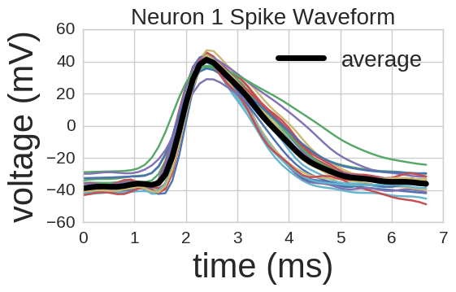

```python
plot_width(data1, 1)
```

```
1.98683858174
```

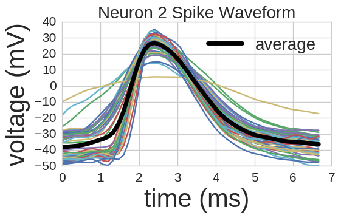

```python
plot_width(data2, 2)
```

```
3.33707444886
```

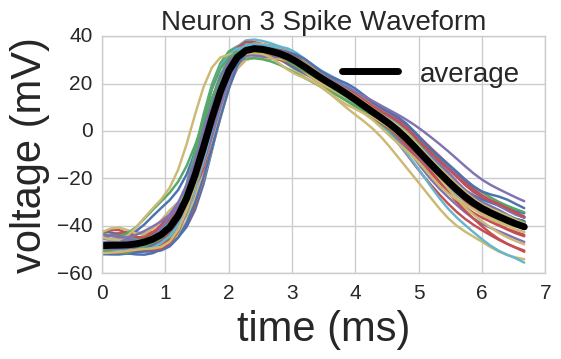

```python
plot_width(data3, 3)
```

```
1.84333531915
```

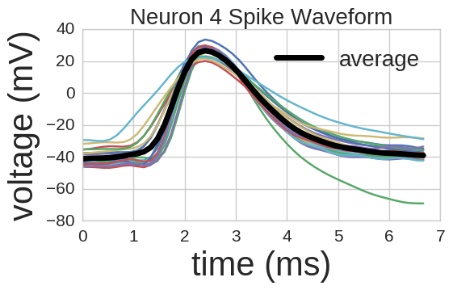

```python
plot_width(data4, 4)
```

```
2.39686459094
```

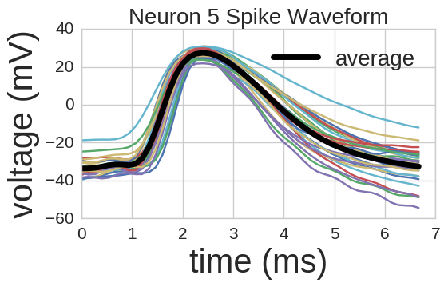

```python
plot_width(data5, 5)
```

Finally, we are interested in seeing whether we can decrease the excitability and spike-width of a 3xTG cell. We will integrate our estimated model of a 3xTG neuron forward in time using a step current as a stimulus. We find that if we increase $\theta_h$ by 10 (from -46 mV) and $\theta_m$ (from -20 mV) by 5 simultaneously (but not independently), we can increase the minimum required step current to produce a spike from about 70 pA to about 270 pA and increase the threshold voltage from about -50 mV to -40 mV. This has no effect on the spike width, however. This can be seen in the first plot below.

```python
dt = 0.4
num_points = 200
epoch = 'Q7A364'
path = 12

initial_conditions = [-70, 0.0, 1.0, 0.0]
time = np.linspace(0.0, dt*num_points - dt, num_points)

#get_data(label_to_neuron, epoch, path)
params, estimate, data, current = load_data(label_to_neuron[epoch],path)
```

```
Neuron3/path_12/params12.dat
```

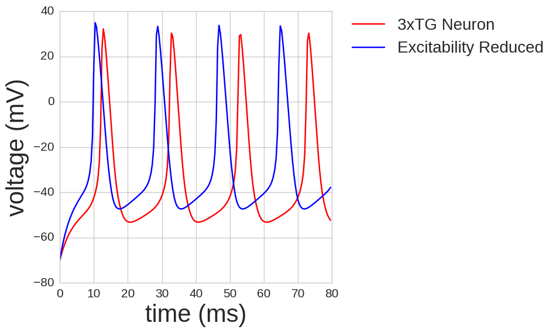

```python
params2 = params.copy()
params2['Vho'] += 10
params2['Vmo'] += 5
fig = plt.figure(figsize = (6,6))
ax = fig.add_subplot(111)

ax.set_xlabel('time (ms)')
ax.set_ylabel('voltage (mV)')
simulation1 = odeint(NaKL, initial_conditions, time, args = (100, params), mxstep=5000000)
simulation2 = odeint(NaKL, initial_conditions, time, args = (300, params2), mxstep=5000000)
ax.plot(time, simulation1[:,0], color = 'red', label = '3xTG Neuron')
ax.plot(time, simulation2[:,0], color = 'blue', label = 'Excitability Reduced')

lgd = ax.legend(bbox_to_anchor=(1.05, 1), loc=2, borderaxespad=0.)
fig.savefig('simulated_treatment.png', bbox_inches='tight')
```

```python
plt.close(fig)
```

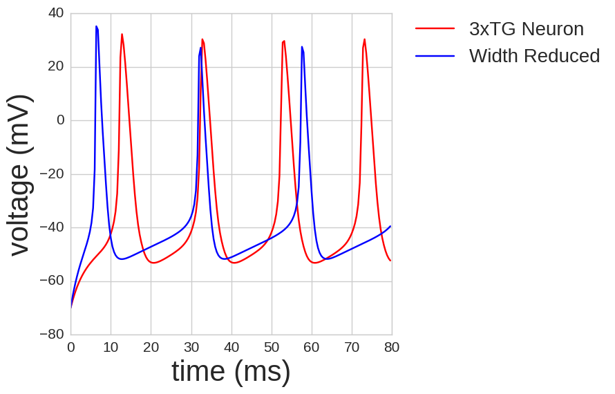

```python
params2 = params.copy()
params2['Vho'] += 10
params2['Vmo'] += 5
#params2['Vno'] += 10
#params2['gK'] *= 1.8
#params2['t0n'] /= 1.5
params2['dtVh'] += 20
params2['t0h'] /= 4.0
#params2['t1h'] /= 4.0
#params2['gNa'] -= 20
plt.close(fig)
fig = plt.figure(figsize = (6,6))
ax = fig.add_subplot(111)

ax.set_xlabel('time (ms)')
ax.set_ylabel('voltage (mV)')
simulation1 = odeint(NaKL, initial_conditions, time, args = (100, params), mxstep=5000000)
simulation2 = odeint(NaKL, initial_conditions, time, args = (300, params2), mxstep=5000000)
ax.plot(time, simulation1[:,0], color = 'red', label = '3xTG Neuron')
ax.plot(time, simulation2[:,0], color = 'blue', label = 'Width Reduced')

lgd = ax.legend(bbox_to_anchor=(1.05, 1), loc=2, borderaxespad=0.)
fig.savefig('simulated_treatment_width.png', bbox_inches='tight')
```

```python
plt.close(fig)
```

```
2.76973834917
2.08475746728
```

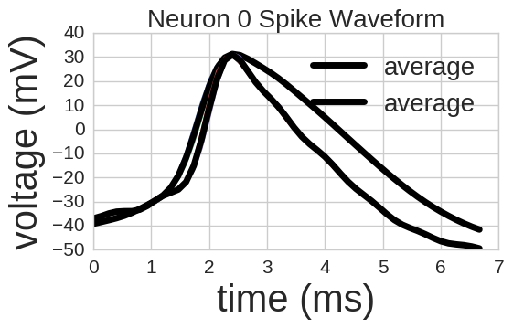

```python
plot_width(simulation1[:,0], 0) #without treatment
plot_width(simulation2[:,0], 0) #with treatment
```

```python
for current in range(-1000,1000):

    simulation = odeint(NaKL, initial_conditions, time, args = (current, params), mxstep=5000000)
    voltage = simulation[:,0]
    if max(voltage) > -20:
        break
    max_voltage = max(voltage)
    max_current = current
max_voltage, max_current
```

```
(-49.032589053206976, 71)
```

```python
for current in range(-1000,1000):

    simulation = odeint(NaKL, initial_conditions, time, args = (current, params2), mxstep=5000000)
    voltage = simulation[:,0]
    if max(voltage) > -20:
        break
    max_voltage = max(voltage)
    max_current = current
max_voltage, max_current
```

```
(-41.027362605348074, 209)
```

```python
#When changing Vh and Vm alone, you can verify that
#max_voltage, max_current = (-39.815474229846892, 273)
```